# Quiz and poll questions

## Talk given to first year medical students

- Topic also relevant to this class.
- Only a few minor changes
  - Different format for the “programming” assignment

## Who am I?

Steve Simon

- PhD Statistics, 1982, U Iowa
- Teach in Biomedical and Health Informatics
  - Previous jobs at CMH, CDC
- Part-time independent statistical consultant (P.Mean Consulting)
- Married to a Pediatric Cardiologist (retired)
- Run 5K and 4 mile races

## Obsessed with computers since 1972

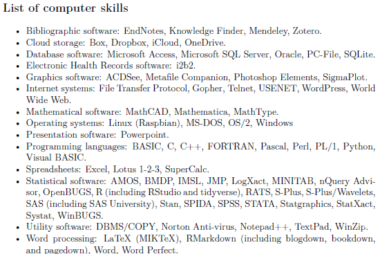

Figure 1. Section on computer skills from my resume

## Worked with health care applications since 1987

- Recent positions
  - Centers for Disease Control and Prevention (1987-1996)
  - Children’s Mercy Hospital (1996-2008)
  - UMKC School of Medicine (2008 to present)
- But…
  - I am not a doctor
  - Still confused about many things
    - Example: Difference between good and bad cholesterol.

## Quiz questions (1/3)

Why does Joel Best call statistics a social construct?

- Statistics are misquoted often on social media.
- Statistics are selected, shaped, and presented by human beings.
- Statistics are used to promote socialism.
- Statistics are dehumanizing.

## Quiz questions (2/3)

What is the main philosophical foundation of empiricism?

- Everything can be reduced to a mathematical equation.
- Experiments can reveal the realities of the world.
- Some questions are impossible to answer.
- We construct our own reality based on our own lived experiences

## Quiz questions (3/3)

What is a major problem with data science?

- Data scientists rely on large amounts of data with uneven quality.
- Models developed by data scientists can lead to loss of privacy.
- Prediction models are a black box that can hide discriminatory intent.
- All of the above.

## First poll question

[figure not shown]

Figure 2. Quote from “Peggy Sue Got Married”

## Second poll question

[figure not shown]

Figure 3. Images of various computers

## Are Statisticians Gods?

I’m helping someone who wants an alternative statistical analysis to the one used by the principal investigator. I’m happy to help and will offer advice about why my approach may be better, but I was warned that the PI considers the analysis chosen to be ordained by the **“Statistical Gods”** at her place of work.